## 1. Briefly explain the policy variations induced by the NBP program.

*What does variable “nbp” = 1 indicate?*

The `nbp` variable is an indicator variable for if an observation is regulated by the Nitrogen Oxides (NOx) Budget Program (NBP). The NBP cap and trade program created to reduce the regional transport of NOx emissions from power plants and other large combustion sources in areas where emission concentration are at its highest.

*b. What does variable “summer” = 1 indicate?*

The `summer` variable is an indicator variable for if it is a summer month

*c. What does variable “post = 1” indicate?*

The `post` variable indicates if the year of a given observation is after 2003

The NBP operated a cap-and-trade system for over 2,500 electricity generating units and industrial boilers in the Eastern and Midwestern U.S. between 2003 and 2008. The market only operated between May 1 and September 30 since ozone pollution is highest during the summer.

([source](http://joseph-s-shapiro.com/research/NOx_Defenses_DGS.pdf)).

## 2. Replicate Panel A (States Participating in NBP) of the Appendix Fig. 2.

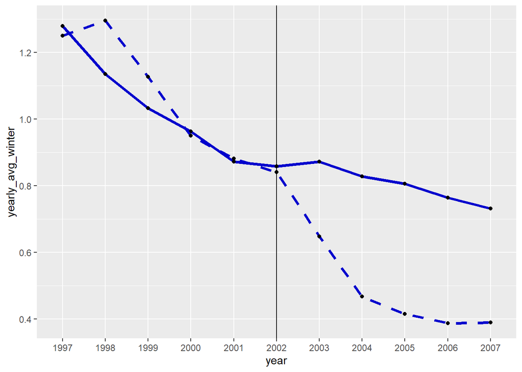

```r
pacman::p_load(ggplot2,
               dplyr,
               magrittr)
# Reading data
nbp = haven::read_dta("nbp.dta")
skim_df = skimr::skim(nbp)

# Cleaning


nbp = nbp %>%
   mutate(
      fips_county = as.character(fips_county),
      year = as.factor(year),
      summer = as.factor(summer),
      state = as.factor(fips_state),
      nbp = as.factor(nbp),
      post_2003 = as.factor(post)) %>%
   rename(emissions = nox_emit,
          county_code = fips_county)

# Creating means by year
merged_df = nbp %>% group_by(year) %>% filter(summer==1 & nbp==1) %>%
   summarise(yearly_avg_summer = mean(emissions))
nbp %>% group_by(year) %>% filter(summer==0 & nbp==1) %>%
   summarise(yearly_avg_winter = mean(emissions)) %>%
   merge(.,merged_df, by="year") -> merged_df


ggplot(merged_df, aes(x = year))+
   geom_line(aes(y = yearly_avg_winter,
                 group = 1),
             color = "mediumblue",
             size = 1.25)+
   geom_point(aes(x = year,y=yearly_avg_winter))+
   geom_line(aes(y = yearly_avg_summer,
                 group = 2),
             color = "mediumblue",
             size = 1.25,
             linetype = "dashed")+
   geom_point(aes(x = year,y=yearly_avg_summer))+
   geom_vline(xintercept = "2002") -> panel_A
panel_A
```

## 3. State the parallel trends assumption underlying Panel A of Appendix Fig. 2. Does the graphical pattern suggest the parallel trends assumption is likely to hold?

The parallel trends assumption states that, although treatment and comparison groups may have different levels of the outcome prior to the start of treatment, their trends in pre-treatment outcomes should be the same ([Ryan et. al.](https://journals.sagepub.com/doi/abs/10.1177/0962280218814570?journalCode=smma#:~:text=The%20parallel%20trends%20assumption%20states,outcomes%20should%20be%20the%20same.)).

Higher temperatures are generally associated with higher ozone levels in general ([EPA](https://www.epa.gov/air-trends/trends-ozone-adjusted-weather-conditions)), so we would expect to see a difference between the two lines on the same graph. Since the policy is only in effect during summer months, then the trends that exist during winter months should continue because they are not affected by the policy. The parallel trends assumption in this context would be holding the assumption that the same trend should can be found in winter months for both the treatment and the control group, and as a result we can assume that changes in our outcome variable (`emissions`) can be attributed to exposure to the treatment (i.e. being an NBP-participating `state`)

## 4. Clearly state, estimate, and report a difference-in-differences regression that examines the effect of the NBP program on NOx emissions corresponding to Panel A of Appendix Fig. 2. Provide a one-sentence interpretation of the coefficient for the interaction term “summer*post”.

To compute the difference-in-difference estimate of the casual effect of the treatment, we can create simple linear models from the data included in the panel representation

```r
nbp %<>% mutate(year = as.integer(as.character(year)))
sum_treat_pre = nbp %>% group_by(year) %>%
   filter(summer==1 & nbp==1 & year<2003)
sum_treat_post = nbp %>% group_by(year) %>%
   filter(summer==1 & nbp==1 & year>=2003)
win_treat_pre = nbp %>% group_by(year) %>%
   filter(summer==0 & nbp==1 & year<2003)
win_treat_post = nbp %>% group_by(year) %>%
   filter(summer==0 & nbp==1 & year>=2003)

mod_tb = lm(emissions~year, data = sum_treat_pre)
mod_ta = lm(emissions~year, data = sum_treat_post)
mod_ub = lm(emissions~year, data = win_treat_pre)
mod_ua = lm(emissions~year, data = win_treat_post)
stargazer::stargazer(mod_tb, mod_ta, mod_ub, mod_ua, type = "text",
                     column.labels = c("TB","TA","UB","UA"))
```

```
##
## ===================================================================================================================
##                                                           Dependent variable:
##                     -----------------------------------------------------------------------------------------------
##                                                                emissions
##                                TB                       TA                       UB                     UA
##                               (1)                      (2)                      (3)                    (4)
## -------------------------------------------------------------------------------------------------------------------
## year                       -0.099***                -0.060***                -0.085***                -0.035
##                             (0.027)                  (0.014)                  (0.026)                (0.026)
##
## Constant                   199.331***               119.963***               170.357***               70.420
##                             (53.703)                 (28.427)                 (52.727)               (53.068)
##
## -------------------------------------------------------------------------------------------------------------------
## Observations                 7,110                    5,925                    7,110                  5,925
## R2                           0.002                    0.003                    0.001                  0.0003
## Adjusted R2                  0.002                    0.003                    0.001                  0.0001
## Residual Std. Error    3.868 (df = 7108)        1.543 (df = 5923)        3.797 (df = 7108)      2.881 (df = 5923)
## F Statistic         13.631*** (df = 1; 7108) 17.672*** (df = 1; 5923) 10.314*** (df = 1; 7108) 1.721 (df = 1; 5923)
## ===================================================================================================================
## Note:                                                                                   *p<0.1; **p<0.05; ***p<0.01
```

```r
sum_treat_pre %>% ungroup() %>% summarise(mean(emissions)) -> TB
sum_treat_post %>% ungroup() %>% summarise(mean(emissions)) -> TA
win_treat_pre %>% ungroup() %>% summarise(mean(emissions)) -> UB
win_treat_post %>% ungroup() %>% summarise(mean(emissions)) -> UA
```

And now to estimate the causal effect of the treatment

```r
calc1 = ((TA-TB)-(UA-UB))
calc1
```

```
##   mean(emissions)
## 1      -0.3731687
```

Or we could define a `lm` model formally defining interaction variables to understand interactions that may be present in our data

```r
mod_lm = nbp %>% mutate(year = as.integer(year)) %>%
   lm(emissions~year+
         nbp+nbp*post_2003+
         post_2003+post_2003*summer+
         summer+summer*nbp,
      data = .)
summary(mod_lm)
```

```
##
## Call:
## lm(formula = emissions ~ year + nbp + nbp * post_2003 + post_2003 +
##     post_2003 * summer + summer + summer * nbp, data = .)
##
## Residuals:
##    Min     1Q Median     3Q    Max
## -1.177 -0.752 -0.532 -0.397 67.413
##
## Coefficients:
##                     Estimate Std. Error t value Pr(>|t|)
## (Intercept)        90.365905  14.327695   6.307 2.86e-10 ***
## year               -0.044961   0.007166  -6.274 3.53e-10 ***
## nbp1                0.596836   0.038227  15.613  < 2e-16 ***
## post_20031          0.222400   0.055153   4.032 5.53e-05 ***
## summer1             0.154348   0.037292   4.139 3.50e-05 ***
## nbp1:post_20031    -0.286792   0.045609  -6.288 3.24e-10 ***
## post_20031:summer1 -0.196647   0.045508  -4.321 1.55e-05 ***
## nbp1:summer1       -0.200792   0.045420  -4.421 9.85e-06 ***
## ---
## Signif. codes:  0 '***' 0.001 '**' 0.01 '*' 0.05 '.' 0.1 ' ' 1
##
## Residual standard error: 2.678 on 55850 degrees of freedom
## Multiple R-squared:  0.008982,   Adjusted R-squared:  0.008858
## F-statistic: 72.32 on 7 and 55850 DF,  p-value: < 2.2e-16
```

The `summer*post` interaction tells us how significant that the characterization of an observation being from a summer month post-2003 has in explaining the relationship that exists in the data.

## 5. Replicate Panel B (States Not Participating in NBP) of the Appendix Fig. 2.

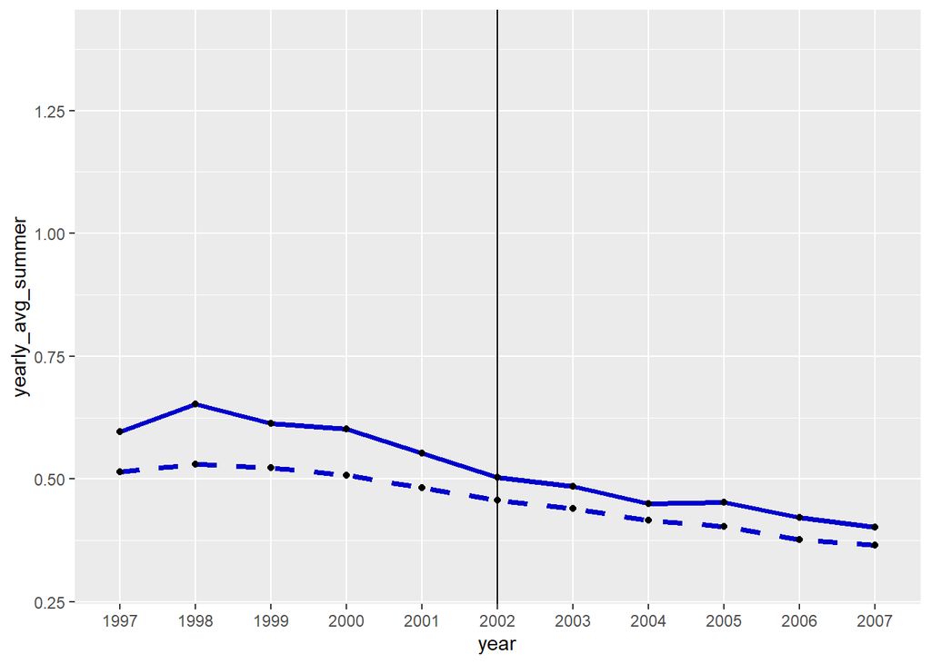

```r
merged_df2 = nbp %>% group_by(year) %>% filter(summer==1 & nbp==0) %>%
   summarise(yearly_avg_summer = mean(emissions))%>%
   mutate(year = as.numeric(year))
nbp %>% group_by(year) %>% filter(summer==0 & nbp==0) %>%
   summarise(yearly_avg_winter = mean(emissions)) %>%
   merge(.,merged_df2, by="year") -> merged_df2
merged_df2 %<>% ungroup() %>% mutate(year = as.factor(year))

p1 = ggplot(merged_df2, aes(x = year))+
   geom_line(aes(y = yearly_avg_summer,
                 group = 1),
             color = "mediumblue",
             size = 1.25)+
   geom_point(aes(y=yearly_avg_summer))


panel_B = p1 +
   geom_line(aes(y = yearly_avg_winter,
                 group = 2),
             color = "mediumblue",
             size = 1.25,
             linetype = "dashed")+
   geom_point(aes(y=yearly_avg_winter)) +
   geom_vline(xintercept = "2002")+
   ylim(0.3,1.4) # Adjusting to scale as previous image
panel_B
```

## 7. Clearly state, estimate, and report a difference-in-differences regression that examines the effect of the NBP program on NOx emissions corresponding to Panel B of Appendix Fig. 2. Provide a one-sentence interpretation of the coefficient for the interaction term “summer*post”.

```r
nbp %<>% mutate(year = as.integer(as.character(year)))
sum_ctrl_pre = nbp %>% group_by(year) %>%
   filter(summer==1 & nbp==0 & year<2003)
sum_ctrl_post = nbp %>% group_by(year) %>%
   filter(summer==1 & nbp==0 & year>=2003)
win_ctrl_pre = nbp %>% group_by(year) %>%
   filter(summer==0 & nbp==0 & year<2003)
win_ctrl_post = nbp %>% group_by(year) %>%
   filter(summer==0 & nbp==0 & year>=2003)

mod_cb = lm(emissions~year, data = sum_ctrl_pre)
mod_ca = lm(emissions~year, data = sum_ctrl_post)
mod_ub = lm(emissions~year, data = win_ctrl_pre)
mod_ua = lm(emissions~year, data = win_ctrl_post)
stargazer::stargazer(mod_tb, mod_ta, mod_ub, mod_ua, type = "text",
                     column.labels = c("CB","CA","UB","UA"))
```

```
##
## ===============================================================================================================
##                                                         Dependent variable:
##                     -------------------------------------------------------------------------------------------
##                                                              emissions
##                                CB                       CA                     UB                   UA
##                               (1)                      (2)                    (3)                  (4)
## ---------------------------------------------------------------------------------------------------------------
## year                       -0.099***                -0.060***                -0.013               -0.019
##                             (0.027)                  (0.014)                (0.014)              (0.015)
##
## Constant                   199.331***               119.963***               26.047               38.556
##                             (53.703)                 (28.427)               (27.825)             (30.878)
##
## ---------------------------------------------------------------------------------------------------------------
## Observations                 7,110                    5,925                  8,124                6,770
## R2                           0.002                    0.003                  0.0001               0.0002
## Adjusted R2                  0.002                    0.003                 -0.00002              0.0001
## Residual Std. Error    3.868 (df = 7108)        1.543 (df = 5923)      2.142 (df = 8122)    1.792 (df = 6768)
## F Statistic         13.631*** (df = 1; 7108) 17.672*** (df = 1; 5923) 0.843 (df = 1; 8122) 1.527 (df = 1; 6768)
## ===============================================================================================================
## Note:                                                                               *p<0.1; **p<0.05; ***p<0.01
```

```r
sum_ctrl_pre %>% ungroup() %>% summarise(mean(emissions)) -> CB
sum_ctrl_post %>% ungroup() %>% summarise(mean(emissions)) -> CA
win_ctrl_pre %>% ungroup() %>% summarise(mean(emissions)) -> UB
win_ctrl_post %>% ungroup() %>% summarise(mean(emissions)) -> UA
```

And now to estimate the causal effect of the treatment

```r
calc2 = ((CA-CB)-(UA-UB))
calc2
```

```
##   mean(emissions)
## 1     -0.04215831
```

```r
calc3 = calc2 - calc1
calc3
```

```
##   mean(emissions)
## 1       0.3310104
```

To look at this relationship from the perspective of a linear model, we can create the following to tell us how significant the triple interaction is at defining the relationship in the data and understanding the true causality of trends, speciafically on NOx emissions. Modeling with DDD allows us to gain a more insightful model in terms of describing causal inference, and since there are parallel trends, we can have confidence in the results from the model.

```r
mod_lm_3D = nbp %>% mutate(year = as.integer(year)) %>%
   lm(emissions~year+
         nbp+nbp*post_2003+
         post_2003+post_2003*summer+
         summer+summer*nbp+
         nbp*post_2003*summer,
      data = .)
summary(mod_lm_3D)
```

```
##
## Call:
## lm(formula = emissions ~ year + nbp + nbp * post_2003 + post_2003 +
##     post_2003 * summer + summer + summer * nbp + nbp * post_2003 *
##     summer, data = .)
##
## Residuals:
##    Min     1Q Median     3Q    Max
## -1.170 -0.801 -0.519 -0.390 67.373
##
## Coefficients:
##                          Estimate Std. Error t value Pr(>|t|)
## (Intercept)             90.401016  14.326137   6.310 2.81e-10 ***
## year                    -0.044961   0.007165  -6.275 3.52e-10 ***
## nbp1                     0.521607   0.043482  11.996  < 2e-16 ***
## post_20031               0.145155   0.059112   2.456 0.014067 *
## summer1                  0.084126   0.042010   2.003 0.045233 *
## nbp1:post_20031         -0.121287   0.064494  -1.881 0.060032 .
## post_20031:summer1      -0.042158   0.062310  -0.677 0.498672
## nbp1:summer1            -0.050333   0.061492  -0.819 0.413063
## nbp1:post_20031:summer1 -0.331010   0.091208  -3.629 0.000285 ***
## ---
## Signif. codes:  0 '***' 0.001 '**' 0.01 '*' 0.05 '.' 0.1 ' ' 1
##
## Residual standard error: 2.677 on 55849 degrees of freedom
## Multiple R-squared:  0.009216,   Adjusted R-squared:  0.009074
## F-statistic: 64.94 on 8 and 55849 DF,  p-value: < 2.2e-16
```